# Goodreads Books Data Exploration

## Data wrangling

[Goodreads](https://www.goodreads.com/) is the world’s largest site for readers and book recommendations.On the Goodreads website, indiviuals can add books to their bookshelves, rate, recommend, and review books. The data that will be explored in this project contains a comprehensive list of 11127 books listed in goodreads, [The source of the goodreads books data](https://www.kaggle.com/jealousleopard/goodreadsbooks). The data includes the bookID, title, authors, average_rating, language_code, number of pages, ratings_count, text_reviews_count, publication_date and publisher.

```python
#importing libraries
import pandas as pd
import seaborn as sn
import matplotlib.pyplot as plt
import numpy as np
import numpy as np
from sklearn.linear_model import LinearRegression
import scipy.cluster.hierarchy as shc
%matplotlib inline
```

### Gathering Data

```python
#Reading dataset with pandas
books= pd.read_csv('goodreads_books.csv')
books.head()
```

|  | bookID | title | authors | average_rating | isbn | isbn13 | language_code | num_pages | ratings_count | text_reviews_count | publication_date | publisher | Unnamed: 12 |
| --- | --- | --- | --- | --- | --- | --- | --- | --- | --- | --- | --- | --- | --- |
| 0 | 1 | Harry Potter and the Half-Blood Prince (Harry ... | J.K. Rowling/Mary GrandPré | 4.57 | 439785960 | 9.78044E+12 | eng | 652 | 2095690 | 27591 | 9/16/2006 | Scholastic Inc. | NaN |
| 1 | 2 | Harry Potter and the Order of the Phoenix (Har... | J.K. Rowling/Mary GrandPré | 4.49 | 439358078 | 9.78044E+12 | eng | 870 | 2153167 | 29221 | 09/01/2004 | Scholastic Inc. | NaN |
| 2 | 4 | Harry Potter and the Chamber of Secrets (Harry... | J.K. Rowling | 4.42 | 439554896 | 9.78044E+12 | eng | 352 | 6333 | 244 | 11/01/2003 | Scholastic | NaN |
| 3 | 5 | Harry Potter and the Prisoner of Azkaban (Harr... | J.K. Rowling/Mary GrandPré | 4.56 | 043965548X | 9.78044E+12 | eng | 435 | 2339585 | 36325 | 05/01/2004 | Scholastic Inc. | NaN |
| 4 | 8 | Harry Potter Boxed Set Books 1-5 (Harry Potte... | J.K. Rowling/Mary GrandPré | 4.78 | 439682584 | 9.78044E+12 | eng | 2690 | 41428 | 164 | 9/13/2004 | Scholastic | NaN |

### Assessing

#### The structure of the dataset

```python
#the shape of the data
books.shape
```

```
(11127, 13)
```

```python
#info of the dataframe
books.info()
```

```
<class 'pandas.core.frame.DataFrame'>
RangeIndex: 11127 entries, 0 to 11126
Data columns (total 13 columns):
bookID                11127 non-null int64
title                 11127 non-null object
authors               11127 non-null object
average_rating        11127 non-null object
isbn                  11127 non-null object
isbn13                11127 non-null object
language_code         11127 non-null object
  num_pages           11127 non-null object
ratings_count         11127 non-null int64
text_reviews_count    11127 non-null int64
publication_date      11127 non-null object
publisher             11127 non-null object
Unnamed: 12           4 non-null object
dtypes: int64(3), object(10)
memory usage: 1.1+ MB
```

```python
#number of unique values in each column
books.nunique()
```

```
bookID                11127
title                 10352
authors                6643
average_rating          213
isbn                  11126
isbn13                  243
language_code            31
  num_pages             999
ratings_count          5294
text_reviews_count     1822
publication_date       3682
publisher              2294
Unnamed: 12               4
dtype: int64
```

### Cleaning

The data is `tidy`, but there are fews `quilty` issues needed to be fixed.

- Some columns have incorrect type.
- Removing rows with zeros values
- The 'isbn','isbn13','Unnamed: 12' columns are unnecessary and can be removed.

#### Making copy of the data

```python
#make copy of the data to start cleaning
df= books.copy()
```

#### Correcting columns type.

```python
#changing the type of The average rating colum
df['average_rating']= pd.to_numeric(df.average_rating, errors='coerce')
#changing the type of The number of pages
df['  num_pages']= pd.to_numeric(df['  num_pages'], errors='coerce')
#testing
df.info()
```

```
<class 'pandas.core.frame.DataFrame'>
RangeIndex: 11127 entries, 0 to 11126
Data columns (total 13 columns):
bookID                11127 non-null int64
title                 11127 non-null object
authors               11127 non-null object
average_rating        11123 non-null float64
isbn                  11127 non-null object
isbn13                11127 non-null object
language_code         11127 non-null object
  num_pages           11123 non-null float64
ratings_count         11127 non-null int64
text_reviews_count    11127 non-null int64
publication_date      11127 non-null object
publisher             11127 non-null object
Unnamed: 12           4 non-null object
dtypes: float64(2), int64(3), object(8)
memory usage: 1.1+ MB
```

#### Removing rows with zeros values

```python
#find out the zeros rows
df.isnull().sum()
```

```
bookID                    0
title                     0
authors                   0
average_rating            4
isbn                      0
isbn13                    0
language_code             0
  num_pages               4
ratings_count             0
text_reviews_count        0
publication_date          0
publisher                 0
Unnamed: 12           11123
dtype: int64
```

#### Dropping unnecessary columns and rows

```python
#dropping unnecessary column
df.drop(['isbn','isbn13','Unnamed: 12'],axis =1,inplace=True)
#drop rows with zeros rating count
df = df[df.ratings_count!= 0]
#Removing rows with zeros values
df.dropna(inplace=True)
```

#### Testing the cleaning process

```python
#testinig data to see the change after cleaning

df.isnull().sum()
```

```
bookID                0
title                 0
authors               0
average_rating        0
language_code         0
  num_pages           0
ratings_count         0
text_reviews_count    0
publication_date      0
publisher             0
dtype: int64
```

```python
df.info()
```

```
<class 'pandas.core.frame.DataFrame'>
Int64Index: 11043 entries, 0 to 11126
Data columns (total 10 columns):
bookID                11043 non-null int64
title                 11043 non-null object
authors               11043 non-null object
average_rating        11043 non-null float64
language_code         11043 non-null object
  num_pages           11043 non-null float64
ratings_count         11043 non-null int64
text_reviews_count    11043 non-null int64
publication_date      11043 non-null object
publisher             11043 non-null object
dtypes: float64(2), int64(3), object(5)
memory usage: 949.0+ KB
```

### To make this analysis more interested, a rating column can be added that contain the meaning of the rating average.

> In goodreads, a book can be rate of 5 stars. Personally, I interpret the rating as:
> - 1 star is disappointed
> - 2 stars is ok
> - 3 stars is good
> - 4 stars is very good
> - 5 stars highly recommended

> In this data there are averages valuse, so this interpretation can adjusted to be in ranges.

```python
# Create a list to store the data
rating = []

for x in df['average_rating']:
    if x >= 2.5 and x < 3.5:
        rating.append('Ok')
    elif x >= 3.5 and  x <3.9:
        rating.append('GOOD')
    elif x >= 3.9  and x < 4.2:
        rating.append('Very Good')
    elif x >= 4.2 :
        rating.append('Highly Recommended')
    else :
        rating.append('Disappointed')
# Create a column for the list
df['rating']= rating
```

```python
#testing the change
df.head()
```

|  | bookID | title | authors | average_rating | language_code | num_pages | ratings_count | text_reviews_count | publication_date | publisher | rating |
| --- | --- | --- | --- | --- | --- | --- | --- | --- | --- | --- | --- |
| 0 | 1 | Harry Potter and the Half-Blood Prince (Harry ... | J.K. Rowling/Mary GrandPré | 4.57 | eng | 652.0 | 2095690 | 27591 | 9/16/2006 | Scholastic Inc. | Highly Recommended |
| 1 | 2 | Harry Potter and the Order of the Phoenix (Har... | J.K. Rowling/Mary GrandPré | 4.49 | eng | 870.0 | 2153167 | 29221 | 09/01/2004 | Scholastic Inc. | Highly Recommended |
| 2 | 4 | Harry Potter and the Chamber of Secrets (Harry... | J.K. Rowling | 4.42 | eng | 352.0 | 6333 | 244 | 11/01/2003 | Scholastic | Highly Recommended |
| 3 | 5 | Harry Potter and the Prisoner of Azkaban (Harr... | J.K. Rowling/Mary GrandPré | 4.56 | eng | 435.0 | 2339585 | 36325 | 05/01/2004 | Scholastic Inc. | Highly Recommended |
| 4 | 8 | Harry Potter Boxed Set Books 1-5 (Harry Potte... | J.K. Rowling/Mary GrandPré | 4.78 | eng | 2690.0 | 41428 | 164 | 9/13/2004 | Scholastic | Highly Recommended |

### Creating a colum that contain the ratio of text review to rating count

> The ratio can be very useful because it can be used as a tool that measures the level of engagement with books that are rated on goodreads.

```python
#creating a colum that contain the ratio of text review to rationg count
df['ratio']= df['text_reviews_count']/df['ratings_count']*100
```

```python
#statistic decription of the ratio
df['ratio'].describe()
```

```
count    11043.000000
mean         7.757436
std          7.262757
min          0.000000
25%          3.275068
50%          6.212706
75%         10.336158
max        100.000000
Name: ratio, dtype: float64
```

```python
df.head()
```

|  | bookID | title | authors | average_rating | language_code | num_pages | ratings_count | text_reviews_count | publication_date | publisher | rating | ratio |
| --- | --- | --- | --- | --- | --- | --- | --- | --- | --- | --- | --- | --- |
| 0 | 1 | Harry Potter and the Half-Blood Prince (Harry ... | J.K. Rowling/Mary GrandPré | 4.57 | eng | 652.0 | 2095690 | 27591 | 9/16/2006 | Scholastic Inc. | Highly Recommended | 1.316559 |
| 1 | 2 | Harry Potter and the Order of the Phoenix (Har... | J.K. Rowling/Mary GrandPré | 4.49 | eng | 870.0 | 2153167 | 29221 | 09/01/2004 | Scholastic Inc. | Highly Recommended | 1.357117 |
| 2 | 4 | Harry Potter and the Chamber of Secrets (Harry... | J.K. Rowling | 4.42 | eng | 352.0 | 6333 | 244 | 11/01/2003 | Scholastic | Highly Recommended | 3.852834 |
| 3 | 5 | Harry Potter and the Prisoner of Azkaban (Harr... | J.K. Rowling/Mary GrandPré | 4.56 | eng | 435.0 | 2339585 | 36325 | 05/01/2004 | Scholastic Inc. | Highly Recommended | 1.552626 |
| 4 | 8 | Harry Potter Boxed Set Books 1-5 (Harry Potte... | J.K. Rowling/Mary GrandPré | 4.78 | eng | 2690.0 | 41428 | 164 | 9/13/2004 | Scholastic | Highly Recommended | 0.395868 |

#### The cleaning process are completed at this point.

## Exploring data

### Univariate exploratory analysis

> Univariate analysis involves the analysis of a single variable. In this section, we will explore each variable at a time.

#### Descriptive statistics for each variable

```python
#Descriptive statistics for each numerical variables
df.describe()
```

|  | bookID | average_rating | num_pages | ratings_count | text_reviews_count | ratio |
| --- | --- | --- | --- | --- | --- | --- |
| count | 11043.000000 | 11043.000000 | 11043.000000 | 1.104300e+04 | 11043.000000 | 11043.000000 |
| mean | 21296.311510 | 3.943228 | 336.765734 | 1.807283e+04 | 545.974735 | 7.757436 |
| std | 13092.495945 | 0.295198 | 241.001338 | 1.128955e+05 | 2585.522060 | 7.262757 |
| min | 1.000000 | 1.000000 | 0.000000 | 1.000000e+00 | 0.000000 | 0.000000 |
| 25% | 10258.000000 | 3.780000 | 194.000000 | 1.100000e+02 | 9.000000 | 3.275068 |
| 50% | 20241.000000 | 3.960000 | 300.000000 | 7.660000e+02 | 48.000000 | 6.212706 |
| 75% | 32098.000000 | 4.140000 | 416.000000 | 5.061500e+03 | 241.500000 | 10.336158 |
| max | 45641.000000 | 5.000000 | 6576.000000 | 4.597666e+06 | 94265.000000 | 100.000000 |

### The distribution of ratings count, text reviews count, and Number of pages

> A histogram is used to plot the distribution of the numeric variables.

```
(50, 1500)
```

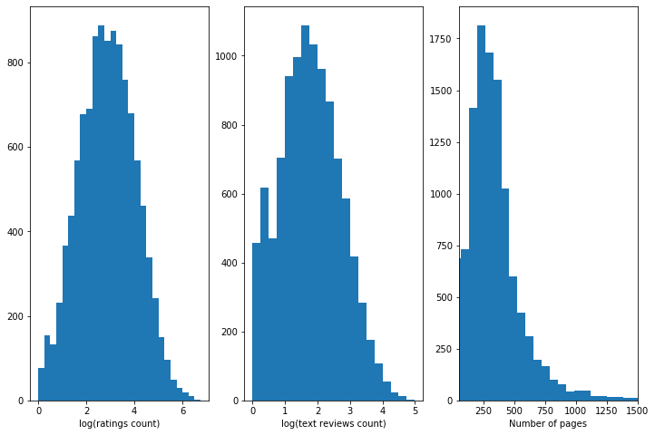

```python
#distribution of num_pages,ratings_count, and text_reviews_count
#prep
np.seterr(divide = 'ignore')
plt.figure(figsize = [12, 8])
# left plot: hist of ratings count
plt.subplot(1, 3, 1)
#plot
log_data = np.log10(df['ratings_count']) # data transform
#scaling
log_bin_edges = np.arange(0, log_data.max()+0.25,0.25)
plt.hist(log_data, bins = log_bin_edges)
plt.xlabel('log(ratings count)')

# central plot: hist of text reviews count
plt.subplot(1, 3, 2)
log_data = np.log10(df['text_reviews_count']) # direct data transform
log_bin_edges = np.arange(0, log_data.max()+0.25,0.25)
plt.hist(log_data, bins = log_bin_edges)
plt.xlabel('log(text reviews count)')

# right plot: # of pages
plt.subplot(1, 3, 3)
plt.hist(df['  num_pages'], bins = 100)
plt.xlabel('Number of pages')
plt.xlim([50,1500]) #setting this limit because # of pages are in range lower than 1500
```

> The distribution of rating count and text reviews count seem to be a normal distribution after applying a logarithmic transform to the data. For the number of pages, most books have between 250 and 500 pages.

### What are the top 20 publishers in goodreads?

```python
#Top 20 publishers
publishers = df.groupby('publisher')['bookID'].count().sort_values(ascending=False).head(20)
```

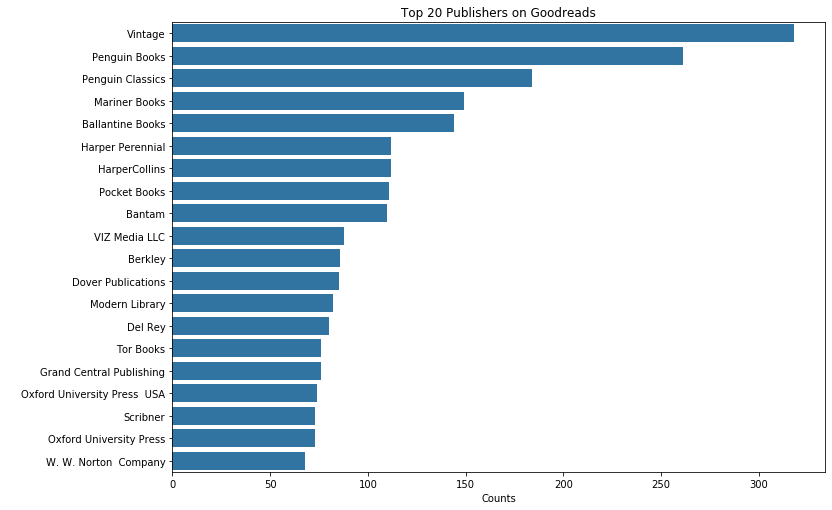

```python
#plot the 20 top publisher based on the goodreads data
#set the color
base_color = sn.color_palette()[0]
# set the plot to the size of A4 paper
fig, ax = plt.subplots()
fig.set_size_inches(11.7, 8.27)
#plot
sn.barplot(publishers, publishers.index, color = base_color)
plt.title('Top 20 Publishers on Goodreads')
plt.xlabel('Counts')
plt.ylabel(' ');
```

> The number of books that published by Vintage, Penguin Books, and Penguin Classic are way higher than the rest of the top 20 list.

### What are the 10 most popular books in goodreads?

[figure not shown]

```python
#The most rated book
ratings_count=df.groupby('title')['ratings_count'].sum().sort_values(ascending=False).head(10)
# plot
fig, ax = plt.subplots()
fig.set_size_inches(10, 6)
sn.barplot(ratings_count, ratings_count.index, color="salmon")
plt.title('The most rated book on Goodreads')
plt.xlabel('Rating Counts')
plt.ylabel('-');
```

> The counts of rating for Twilight is almost double the other book in this list.

### Who are the top 10 authors in goodreads?

[figure not shown]

```python
#Top 10 author
authors= df['authors'].value_counts().head(10)
#plot
fig, ax = plt.subplots()
fig.set_size_inches(10, 5)
sn.barplot(authors, authors.index,color = base_color)
plt.title('Top 10 Authors on Goodreads')
plt.xlabel('Book Counts')
plt.ylabel('-');
```

> In goodreads, P.G Wodehouse and Stephen King are equally famous.

## Bivariate exploratory analysis

> Bivariate exploratory analysis involves the analysis of two variables to determine the empirical relationship between them.

### Pairs plot

> A pairs plot allows us to see relationships between two variables.

```python
#pairs plots of the numerical variables
#define variables
df_numeric = ['average_rating' ,'  num_pages' ,'ratings_count','text_reviews_count','ratio']
#plot
sn.pairplot(df[df_numeric], diag_kind='kde')
```

[output not shown]

> We can see that there is a relationship between a rating count and text reviews count.

### The relationship between rating count and text reviews count

> A linear regression is used to modeling the relationship between a rating count and text reviews count.

```python
#relationship between rating count and text reviews count
#sklearn.linear_model.LinearRegression
#define the model
model = LinearRegression()
#set the variable x and y
x = df['ratings_count']
y = df['text_reviews_count']
#reshape
x= x.values.reshape(-1, 1)
y= y.values.reshape(-1, 1)
#fitting model
model.fit(x, y)
model = LinearRegression().fit(x, y)
y_pred = model.predict(x)
#Correlation Coefficient
r_sq = model.score(x, y)
r_sq #The Correlation Coefficient
```

[output not shown]

```python
# visualizing the relationship between rating count and text reviews count
# set the plot to the size of A4 paper
#prep
fig, ax = plt.subplots()
fig.set_size_inches(10, 8)
#plot
plt.scatter(x, y)
#reg line
plt.plot(x, y_pred, color='red');
#labels and title
plt.title('Ratings Count Vs Text Reviews Count')
plt.xlabel('Ratings Count')
plt.ylabel('Text Reviews counts')
plt.xlim([0,3e6]);
```

[output not shown]

> The correlation Coefficient of this analysis is equal to 0.76 which indicates a relatively strong correlation. Whith higher ratings count, there is a high reviews with text and thish finding is reasonable and not suprizing.

### Multivariate exploratory analysis

### What are the distributions of ratings count with respect to the rating categories?

> In this section, we will create a subset datafram with the 200 most rated books,and visualize their statistics to answer this question.

#### Creating a subset with the 200 most rated books

```python
#creat a subset with the 200 most rated books
df_highest = df.nlargest(200,['ratings_count'])
df_highest.head()
```

##### Creating box plots to show distributions with respect to the categories.

```python
#creating two plots to show the distribution of rating count and text reviews count

# left plot: hist of ratings count
plt.figure(figsize = [12, 6])
plt.subplot(1, 2, 1)
sn.boxplot(x="rating", y="ratings_count", data=df_highest)
plt.ylim([0,2e6])
plt.xlabel('Rating')
plt.ylabel('Ratings Count')
plt.xticks(rotation=90,fontsize = 12);
# Right plot: hist of text reviews count
plt.subplot(1, 2, 2)
sn.boxplot(x="rating", y="text_reviews_count", data=df_highest)
plt.ylim([0,4e4])
plt.xlabel('Rating')
plt.ylabel('Text Reviws Count')
plt.xticks(rotation=90,fontsize = 12);
```

[output not shown]

> From the left plot, we can see that the median (the line that divides the box into two parts) of the ratings count related to 'Highly Recommended' rating is approximetly equal to 'Ok' rating. Most of the ratings count for the 'Good' rating are greater than the mdian and the distribution is positively skewed.

> The right plot, 'Highly Recommended' rating has the greatest madian text review counts.

### Which publishers have the highest ratings average?

In this part, I fillter the data based on publishers which books count is larger than 100 books. Then, the distributions of the averages rate visulized by using violin plots.

> A violin plot shows the distribution of quantitative data across several levels of one (or more) categorical variables such that those distributions can be compared.

```python
#new dataframe for publishers with > 100 books
df_publisher = df[df.groupby('publisher')['publisher'].transform('size') > 100]
df_publisher.head()
```

```python
#violin ploting
#size of the graph
plt.figure(figsize = [10, 8])
#plot
sn.violinplot(data = df_publisher, x = 'publisher', y = 'average_rating')
#labels and title
plt.xlabel(' ')
plt.ylabel('Average Rating')
#rotaion of the object in x axis
plt.xticks(rotation=90,fontsize = 14);
```

[output not shown]

> For violin plot, the wider sections represent a higher probability that most of the population will have the given value; the skinnier sections represent a lower probability.Therefore, Pengun Classics and Pocket Books rating averages are around the mean which is closer to 4 star. For HarperColins,the wider section is higher than the center which indicates that a large number of books got more star than 4.

## The distribution of rating based on authors

Here, I will look for each author at time. The authors that will be considered are the ones with more that 25 books. I will select three and visualize their Kernel Distribution estimation based on their rating and the ratio of text reviews count to the ratings count.

> The seaborn.kdeplot fit and plot a univariate or bivariate kernel density estimate.It represents the probability distribution of the data values as the area under the plotted curve.It is useful to visualize the shape data.

```python
#looking for authors with more than 25 books
df_author = df[df.groupby('authors')['authors'].transform('size') > 25]
df_author['authors'].unique()
```

[output not shown]

> We find a list with 9 authors, and Stephen King, P.G. Wodehouse, and Agatha Christie are selected.

```python
# Creatinf dataframe for Stephen King books
df_king=df[df['authors']=='Stephen King']
df_king.rating.unique()
```

```python
# Creatinf dataframe for P.G. Wodehouse books
df_Wodehouse=df[df['authors']=='P.G. Wodehouse']
df_Wodehouse.rating.unique()
```

```python
# Creatinf dataframe for Agatha Christie books
df_Christie = df[df['authors']=='Agatha Christie']
df_Christie.rating.unique()
```

```python
#creatin three plots for the selected authors
#seting the size of the plots
plt.figure(figsize = [16, 8])
#first plot for Stephen King books
plt.subplot(1, 3, 1)
sn.kdeplot(df_king.ratio[df_king['rating'] == 'Ok'], shade=True, color="deeppink", label="Ok", alpha=.7)
sn.kdeplot(df_king.ratio[df_king['rating'] == 'Very Good'], shade=True, color="g", label="Very Good", alpha=.7)
sn.kdeplot(df_king.ratio[df_king['rating'] == 'GOOD'], shade=True, color="orange", label="Good", alpha=.7)
sn.kdeplot(df_king.ratio[df_king['rating'] == 'Highly Recommended'], shade=True, color="grey", label="Highly Recommended", alpha=.7)
plt.title('Stephen King')
#second plot : P.G. Wodehouse books
plt.subplot(1, 3, 2)
sn.kdeplot(df_Wodehouse.ratio[df_Wodehouse['rating'] == 'Very Good'], shade=True, color="g", label="Very Good", alpha=.7)
sn.kdeplot(df_Wodehouse.ratio[df_Wodehouse['rating'] == 'GOOD'], shade=True, color="orange", label="Good", alpha=.7)
sn.kdeplot(df_Wodehouse.ratio[df_Wodehouse['rating'] == 'Highly Recommended'], shade=True, color="grey", label="Highly Recommended", alpha=.7)
plt.title('P.G. Wodehouse')
#third plot : Agatha Christie
plt.subplot(1, 3, 3)
sn.kdeplot(df_Christie.ratio[df_Christie['rating'] == 'Ok'], shade=True, color="deeppink", label="Ok", alpha=.7)
sn.kdeplot(df_Christie.ratio[df_Christie['rating'] == 'Very Good'], shade=True, color="g", label="Very Good", alpha=.7)
sn.kdeplot(df_Christie.ratio[df_Christie['rating'] == 'GOOD'], shade=True, color="orange", label="Good", alpha=.7)
sn.kdeplot(df_Christie.ratio[df_Christie['rating'] == 'Highly Recommended'], shade=True, color="grey", label="Highly Recommended", alpha=.7)
plt.title('Agatha Christie')
```

[output not shown]

> Even though Stephen King is the most popular author in goodreads, most of his books are rated in range of Ok and Good which is surprising. The majority of Agatha Christie books rated as highly recommended. And P.G. Wodehouse books received a Very Good and highly recommended.

## Summary

The [Goodreads](https://www.goodreads.com/) data is interesting and we can perform a variety of analysis and get insights. In this project we looked at different aspects of the data.

- There is a correlation between the number of rating and the count of text reviews.The correlation Coefficient is 0.76 which shows a strong correlation.
- Pengun Classics and Pocket Books rating averages are closer to 4 star. For HarperColins,a large number of books got more star than 4.
- We found out that quantity does not equal quality. For example , Stephen King is the most popular author in goodreads, but his books are rated in range of Ok and Good.

> [The source of the goodreads books data](https://www.kaggle.com/jealousleopard/goodreadsbooks).